# genomicSimulation Vignette

Kira Villiers

2021-03-23

```r
library(genomicSimulation)
```

# 1 Introduction

This package can be used to create ‘digital twins’ of breeding schemes. It offers scripting functions to simulate crossing and genomic selection on SNP markers. It was created with self-pollinated plant species in mind.

The package itself is an interface to a set of C functions. Using C to perform the computation-intensive parts of simulation allows for quick runtimes - however, since this package is still mostly just a wrapper around those core C functions, it produces most of its output by writing to files rather than saving values to R.

# 2 Details and Methodology

## 2.1 Methodology: Calculating Genetic Estimated Breeding Values

The simulation loads the effect file into a set of vectors, each vector containing the effect values for each SNP for a particular allele. When the simulation is then instructed to calculate GEBVs for a genotype, it creates a vector containing how many copies of a particular allele the genotype contains at each SNP, then multiplies this vector with the effect vector for that allele. It repeats this process for each allele it has an effect vector for, then adds up the results to produce one final value.

## 2.2 Methodology: Simulating Meiosis

To create a cross, the simulation generates gametes independently for the two parents. No distinction is made between male and female parent.

For each chromosome number, the number of crossovers to occur in the simulated meiosis are drawn from a Poisson distribution with parameter = [length of the chromosome in Morgans], where length of the chromosome is pre-calculated as the distance between the first and last SNP that the `SimData` knows are in that chromosome. The positions of those crossovers along the chromosome are then drawn from a uniform distribution, which is why the use of a linkage map (so that distances correspond to likelihood of crossover) is recommended over use of a physical map. Finally, a random logical value (0 or 1) is drawn to choose which of the parent’s chromosomes to start with.

Note that this means that allele order in parents matters.

The R package uses the R random generators, so will follow the R seed.

This procedure is displayed visually in the images below.

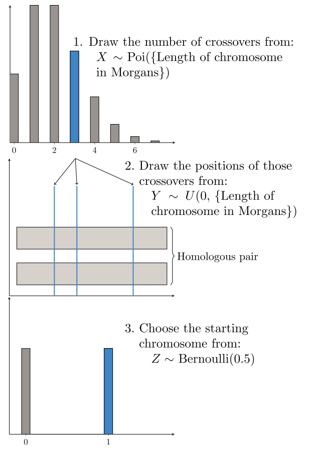

Random draws for each chromosome

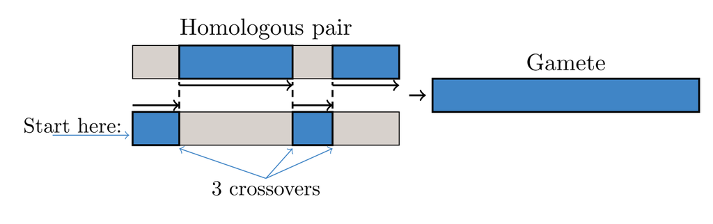

Using those random values to generate a gamete

## 2.3 Methodology: Counting Recombinations

Extra functionality is available for estimating where crossovers occured in producing certain genotypes. This is offered by the `find.crossovers` and `find.plot.crossovers` functions. The difference between the two is that after crossovers points are found, as well as saving the results matrix to a file `find.plot.crossovers` produces an R plot, as shown below. It assumes the child is mostly homozygous.

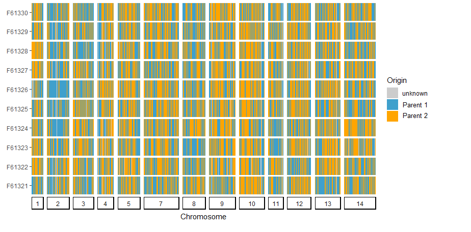

An example plot produced by the crossover finder function with certainty=FALSE. The lines plotted were produced by crossing the two parents then selfing for 6 generations. This produces a large number of crossover events.

To identify crossovers, the code starts at the beginning of each chromosome for the current child line, and reads through to find SNPs where the parents differ (and so therefore the provenance of the allele the child has there can be determined).

The functions have two parameters that affect the way the crossover counting works: `window.size` and `certainty`.

If the `certainty` setting is `True`, then SNPs where the provenance of an allele cannot be determined are marked with a 0, representing unknown parentage. If the `certainty` setting is `False`, when the provenance of an allele is unknown, the parentage at that SNP is set to the same parent as the most recent SNP with known parentage.

The `window.size` parameter should be an odd positive integer. The window size is the number of SNPs that are observed at a time. Only if the alleles of the child at all SNPs in the window can come from one parent, and that same sequence cannot come from the other, is the parentage at that SNP considered known.

# 3 Speed

On a consumer-model laptop running RStudio version 1.2.5019, the process of loading 50 founder lines and 5112 SNPs took on average 0.64 seconds.

A call to `cross.randomly` to generate 100,000 ($10^5$) offspring from those founders took on average 2 seconds to run. Since all crossing functions use the same methodology, this time should be fairly representative of the speed of any crossing function.

Output (writing to files) adds significant delays. The same command, with save-as-you-go output of GEBVs and pedigrees requested, took approximately 20 seconds to run. With save-as-you-go output of GEBVs, pedigrees, and genotypes (the latter being a significantly larger file size), the function call took approximately 120 seconds.

The C-level functions make no attempt to parallelise execution.

# 4 Package-Specific Details

## 4.1 Understanding `sim.data`

This package’s set of working data is stored a C struct called `SimData`. An external pointer to the struct is saved in a package-global R variable called `sim.data$p`. `sim.data$p` is not visible during regular use.

To reset the simulation/clear it of all data, the function `clear.simdata()` is provided.

### 4.1.1 Markers

Each `SimData` is given a list of SNPs and a map for positioning these in the genome on creation. These details cannot be changed after creation without clearing the `SimData`. The `SimData` object saves names of markers as-is, as long as the name is under 30 characters long. Behaviour is undefined if any marker name is longer than 30 characters.

Becauses the `SimData` stores its SNPs in genome order, and so any outputs produced will have the SNP markers ordered according to the genetic map loaded at its creation.

### 4.1.2 Effects

The simulation cannot run without having a genetic map for the SNPs it tracks. However, it can run with no effect values loaded, so in cases where there is no need to be using GEBVs, there is no need to provide an effect file.

Only one ‘set’ of effect values can be loaded at a time. That is, the simulation only has one way of calculating GEBVs at a time.

### 4.1.3 Genotypes

Each genotype/line may or may not be allocated a name. If loading names from a file, behaviour is undefined if any line name is longer than 30 characters.

## 4.2 Understanding Groups

The SimData allows for lines to be treated in groups/categories. Automatically, the lines loaded from separate files are allocated to separate groups. Each crossing function also places the lines it produces in a new group.

A line can only belong to one group, so functions that overwrite allocations (eg `make.group`) effectively pull lines out of their old group and put them in a new one. There’s therefore no chance of attempting to delete lines via `delete.group` that have already been deleted.

Group numbers are natural numbers starting at 1. Group numbers are not guaranteed to be allocated sequentially, though functions usually choose the lowest currently-unused valid group number when creating their new groups.

Each separate function call that adds new genotypes to the internal `SimData` allocates them to a new, separate group.

Every function except those that pull data into R (functions whose names begin with `see.`) return either one integer or a vector of integers. If the integer is 0, it means the function succeeded but it is not a function that acts on groups. Otherwise, the return value is the group number of the group(s) that were created.

## 4.3 Understanding Identifiers

There are three categories of identifiers that may pop up during use of the simulation.

1. Group numbers, which were discussed in the section above. They are non-negative integers that define a set of lines. Any number of lines can share a group number, and a line’s group number may be changed over the course of the simulation.
2. IDs. These are non-negative integers that are unique to a particular genotype for the lifetime of the `SimData`. IDs are used for tracking pedigree thanks to this uniqueness feature. However, genotypes are not guaranteed to have an ID: genotypes created during crossing with the setting `give.ids` set to FALSE will not be allocated IDs and will have 0 instead.
3. Indexes. These represent the position/column number in the internal matrix at which the genotype is stored. They are therefore unique to the genotype but not continuous over the lifetime of the `SimData`, because when genotypes/columns are deleted the column numbers of the matrix change. Because, unlike for IDs, every genotype is guaranteed to have an index, functions like `make.group` and `cross` that act on particular genotypes generally take indexes as inputs. Since indexes can change, however, it is important to not place a `delete.group` call between getting and using indexes.

## 4.4 Understanding Output Methods

There are three sets of functions to get output from the simulation.

- The first involves calling a function to save data to a file (`save.` family functions).
- The second involves saving the data from a cross as you go (`save.` settings in crossing function settings). This is useful in conjunction with the setting `retain=FALSE` when generating more genotypes than will fit in memory, because in save-as-you-go mode the simulation saves the data to a file every 1000 lines (and if `retain=FALSE` it can then delete them and free up memory). However, this method is more limited than full `save.` functions in that it always uses the default printing format for that data type and only prints the genotypes being generated by that crossing call.
- The third (and most limited) is to use the `see.` family of functions to pull data into R. The family of `see.` functions will be expanded in future, but for now is fairly limited in scope.